# Self-Driving Car Engineer Nanodegree

## Project: Build a Traffic Sign Recognition Classifier

In this notebook, a template is provided for you to implement your functionality in stages, which is required to successfully complete this project. If additional code is required that cannot be included in the notebook, be sure that the Python code is successfully imported and included in your submission if necessary.

In addition to implementing code, there is a writeup to complete. The writeup should be completed in a separate file, which can be either a markdown file or a pdf document. There is a [write up template](https://github.com/udacity/CarND-Traffic-Sign-Classifier-Project/blob/master/writeup_template.md) that can be used to guide the writing process. Completing the code template and writeup template will cover all of the [rubric points](https://review.udacity.com/#!/rubrics/481/view) for this project.

The [rubric](https://review.udacity.com/#!/rubrics/481/view) contains "Stand Out Suggestions" for enhancing the project beyond the minimum requirements. The stand out suggestions are optional. If you decide to pursue the "stand out suggestions", you can include the code in this Ipython notebook and also discuss the results in the writeup file.

**Note:** Code and Markdown cells can be executed using the **Shift + Enter** keyboard shortcut. In addition, Markdown cells can be edited by typically double-clicking the cell to enter edit mode.

## Step 0: Load The Data

```python
# Load pickled data
import pickle

# TODO: Fill this in based on where you saved the training and testing data

training_file = './traffic_signs_data/train.p'
validation_file = './traffic_signs_data/valid.p'
testing_file = './traffic_signs_data/test.p'

with open(training_file, mode='rb') as f:
    train = pickle.load(f)
with open(validation_file, mode='rb') as f:
    valid = pickle.load(f)
with open(testing_file, mode='rb') as f:
    test = pickle.load(f)

X_train, y_train = train['features'], train['labels']
X_valid, y_valid = valid['features'], valid['labels']
X_test, y_test = test['features'], test['labels']
```

```python
import matplotlib.pyplot as plt
import csv
import cv2 as cv2

def readTrafficSigns(rootpath):
    '''Reads traffic sign data for German Traffic Sign Recognition Benchmark.

    Arguments: path to the traffic sign data, for example './GTSRB/Training'
    Returns:   list of images, list of corresponding labels'''
    images = [] # images
    labels = [] # corresponding labels
    # loop over all 42 classes
    for c in range(0,43):
        prefix = rootpath + '/' + format(c, '05d') + '/' # subdirectory for class
        gtFile = open(prefix + 'GT-'+ format(c, '05d') + '.csv') # annotations file
        gtReader = csv.reader(gtFile, delimiter=';') # csv parser for annotations file
        next(gtReader) # skip header
        # loop over all images in current annotations file
        for row in gtReader:
            image = plt.imread(prefix + row[0])
            image = cv2.resize(image, (32, 32))
            images.append(image) # the 1th column is the filename
            labels.append(row[7]) # the 8th column is the label
        gtFile.close()
    return images, labels
```

```python
# Read additional training data and concatenate to existing data.
import numpy as np
#from  sklearn.model_selection import train_test_split

#more_data_path = './traffic_signs_data/GTSRB/Training/Images'
#images, labels = readTrafficSigns(more_data_path)

#images = np.asarray(images)
#labels  = np.asarray(labels, dtype=np.int32)

#images_train, images_test, labels_train, labels_test = train_test_split(images, labels, test_size=0.2, random_state=1)

#images_train, images_valid, labels_train, labels_valid = train_test_split(images_train, labels_train, test_size=0.2, random_state=1)
```

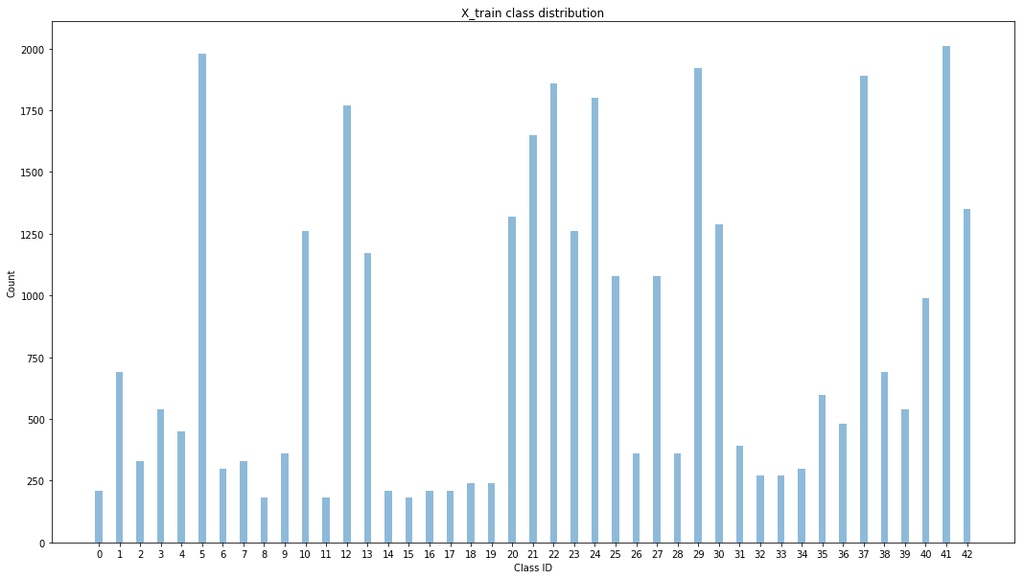

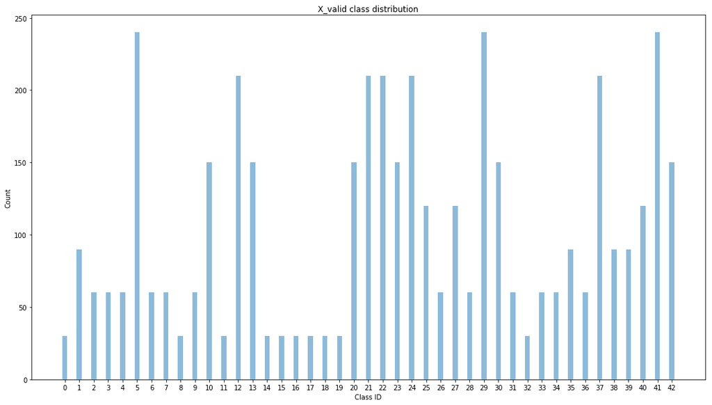

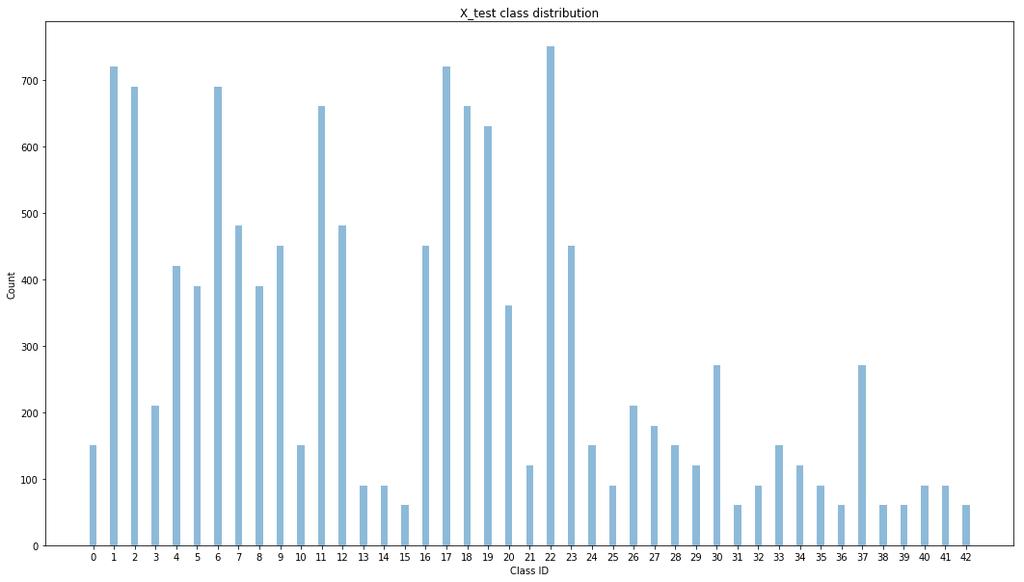

```python
# Visualize pre-augmented data
import matplotlib.pyplot as plt
import tensorflow as tf
import numpy as np
import random
import pandas
from collections import Counter
with tf.device('/cpu:0'):
    df = pandas.read_csv('signnames.csv')
    data = df.values

%matplotlib inline
#%matplotlib notebook
unique_tensor, idx_tensor, counts_tensor = tf.unique_with_counts(y_train)
with tf.Session() as sess:
    counts_train = sess.run(counts_tensor)
    idx_train = sess.run(idx_tensor)
count_aray = np.array(counts_train)
x_axis = df['ClassId']
y_pos = np.arange(len(x_axis))
y_axis = [np.min(count_aray), np.max(count_aray)]
plt.figure(figsize= [18, 10])
plt.bar(x_axis, count_aray[:], align='center', alpha=0.5, width = 0.35
       )
plt.xticks(y_pos, x_axis)
plt.ylabel('Count')
plt.xlabel('Class ID')
plt.title('X_train class distribution')
#fig_size = plt.rcParams["figure.figsize"]
#print(fig_size)
#plt.rcParams['figure.figsize'] = [10, 6]

plt.show()
unique_tensor, idx_tensor, counts_tensor = tf.unique_with_counts(y_valid)
with tf.Session() as sess:
    counts = sess.run(counts_tensor)
count_aray = np.array(counts)
x_axis = df['ClassId']
y_pos = np.arange(len(x_axis))
y_axis = [np.min(count_aray), np.max(count_aray)]
plt.figure(figsize= [18, 10])
plt.bar(x_axis, count_aray[:], align='center', alpha=0.5, width = 0.35
       )
plt.xticks(y_pos, x_axis)
plt.ylabel('Count')
plt.xlabel('Class ID')
plt.title('X_valid class distribution')
#fig_size = plt.rcParams["figure.figsize"]
#print(fig_size)
#plt.rcParams['figure.figsize'] = [10, 6]

plt.show()
unique_tensor, idx_tensor, counts_tensor = tf.unique_with_counts(y_test)
with tf.Session() as sess:
    counts = sess.run(counts_tensor)
count_aray = np.array(counts)
x_axis = df['ClassId']
y_pos = np.arange(len(x_axis))
y_axis = [np.min(count_aray), np.max(count_aray)]
plt.figure(figsize= [18, 10])
plt.bar(x_axis, count_aray[:], align='center', alpha=0.5, width = 0.35
       )
plt.xticks(y_pos, x_axis)
plt.ylabel('Count')
plt.xlabel('Class ID')
plt.title('X_test class distribution')
#fig_size = plt.rcParams["figure.figsize"]
#print(fig_size)
#plt.rcParams['figure.figsize'] = [10, 6]

plt.show()
```

```python
max_count = np.max(counts_train)
n_classes = len(counts_train)
#X_train_tensor = tf.convert_to_tensor(X_train)
#y_train = tf.convert_to_tensor(y_train)
```

idx_temp_aray = np.array(np.nonzero(idx_train == 0))

# idx_temp_aray = np.reshape(idx_temp_aray, [idx_temp_aray.shape[1]])

X_train_temp = np.tile(X_train_temp, ((max_count // count_temp) ,1, 1,1) )

```
X_train_aray = np.concatenate((X_train_aray, X_train_temp))

y_train_aray = np.concatenate((y_train_aray, y_train_temp))
```

import tensorflow as tf

# flipped_image_labels = []

# shape = [X_train.shape[0], X_train.shape[1], X_train.shape[2], X_train.shape[3]]

# x = tf.placeholder(dtype = X_train.dtype, shape = shape)

# X_flipped_1 = tf.placeholder(dtype = tf.int32, shape = shape)

# X_flipped_2 = tf.placeholder(dtype = tf.int32, shape = shape)

```
X_train_aray = y_train_aray = []
#idx_temp_aray = tf.where(idx_train==0)
#print(idx_temp_aray)
#X_train_temp = tf.gather(X_train_tensor, idx_temp_aray)
idx_temp_aray = np.array(np.nonzero(idx_train == 0))
idx_temp_aray = idx_temp_aray.T
idx_temp_aray = np.reshape(idx_temp_aray, (-1))
#idx_temp_aray = np.reshape(idx_temp_aray, [idx_temp_aray.shape[1]])
idx_temp_aray = np.random.choice(idx_temp_aray, data_aug_lim, replace=False)


X_train_temp = tf.gather(X_train_tensor, idx_temp_aray)
y_train_temp = y_train[idx_temp_aray]
#count_temp = len(y_train_temp)

X_flipped_1 = tf.cast(tf.image.flip_up_down(X_train_temp), X_train_tensor.dtype)
X_flipped_2 = tf.cast(tf.image.flip_left_right(X_train_temp),  X_train_tensor.dtype)
#X_train_temp = tf.tile(X_train_temp, (data_aug_lim,1, 1,1) )

#y_train_temp = tf.tile(y_train_temp, data_aug_lim)

X_train_aray = tf.concat((X_flipped_1, X_flipped_2), axis = 0)
y_train_aray = tf.concat((y_train_temp, y_train_temp), axis = 0)


for i in range(1, n_classes):
    idx_temp_aray = np.array(np.nonzero(idx_train == i))
    idx_temp_aray = idx_temp_aray.T
    idx_temp_aray = np.reshape(idx_temp_aray, (-1))
    X_train_temp =  tf.gather(X_train_tensor, idx_temp_aray)
    y_train_temp = y_train[idx_temp_aray]
    #count_temp = len(X_train_temp)
    X_flipped_1 = tf.cast(tf.image.flip_up_down(X_train_temp), X_train_tensor.dtype)
    X_flipped_2 = tf.cast(tf.image.flip_left_right(X_train_temp),  X_train_tensor.dtype)

    X_train_aray = tf.concat((X_train_aray, X_flipped_1, X_flipped_2), axis = 0)
    y_train_aray = tf.concat((y_train_aray, y_train_temp, y_train_temp), axis = 0)


X_train_aray = tf.concat((X_train_tensor, X_train_aray), axis = 0)
y_train_aray = tf.concat((y_train, y_train_aray), axis = 0)

        #for i in range(0,X_train.shape[0], 10000):
    #   x = X_train[i]
    #   y  = y_train[i]
    #x = tf.placeholder(dtype = tf.float32, shape = shape)
    #  flipped_images.append(tf.image.flip_up_down(x))
    # flipped_image_labels.append(y)
    # flipped_images.append(tf.image.flip_left_right(x))
    #  flipped_image_labels.append(y)
    # flipped_images.append(tf.image.random_flip_up_down(x))
    # flipped_image_labels.append(y)
    # flipped_images.append(tf.image.random_flip_left_right(x))
    # flipped_image_labels.append(y)


    #session.run(tf.global_variables_initializer())
    #X_flipped_1 = session.run(X_flipped_1, feed_dict={x: X_train_tensor})
    #X_flipped_2 = session.run(X_flipped_2, feed_dict={x: X_train_tensor})

    #eval1 = X_flipped_1.eval(session)
    #eval2 = X_flipped_2.eval(session)
#X_train_tensor = tf.concat((X_train_tensor, X_flipped_1, X_flipped_2), axis = 0)
#y_train_orig = y_train
#y_train = tf.concat((y_train_orig, y_train_orig[0:data_aug_lim], y_train_orig[0:data_aug_lim] ), axis = 0)
X_train_tensor = X_train_aray
y_train = y_train_aray
print(X_train_tensor.shape, y_train.shape)
```

# angles_shape = [shape[0]]

data_aug_lim = 2010

# x = tf.placeholder(dtype = X_train.dtype, shape = shape)

x = X_train_tensor

# angles = tf.placeholder(dtype = tf.float32, shape = angles_shape)

with tf.device('/cpu:0'):

```
unique_tensor, idx_tensor, counts_tensor = tf.unique_with_counts(y_train)

with tf.Session() as sess:
    #counts_train = sess.run(counts_tensor)
    idx_train = sess.run(idx_tensor)

X_train_aray = y_train_aray = []

idx_temp_aray = np.array(np.nonzero(idx_train == 0))
idx_temp_aray = idx_temp_aray.T
idx_temp_aray = np.reshape(idx_temp_aray, (-1))
idx_temp_aray = np.random.choice(idx_temp_aray, data_aug_lim, replace=False)


X_train_temp = tf.gather(X_train_tensor, idx_temp_aray)
y_train_temp = tf.gather(y_train, idx_temp_aray)



angles_45 = np.full((data_aug_lim), 0.785398)
angles_90 = np.full((data_aug_lim), 1.5708)
angles_135 = np.full((data_aug_lim), 2.35619)
angles_180 = np.full((data_aug_lim), 3.14159)
angles_225 = np.full((data_aug_lim), 3.92699)
angles_270 = np.full((data_aug_lim), 4.79966)
angles_315 = np.full((data_aug_lim), 5.49779)

X_rotate_1 = tf.contrib.image.rotate(X_train_temp, angles_45)
X_rotate_2 = tf.contrib.image.rotate(X_train_temp, angles_90)
X_rotate_3 = tf.contrib.image.rotate(X_train_temp, angles_135)
X_rotate_4 = tf.contrib.image.rotate(X_train_temp, angles_180)
X_rotate_5 = tf.contrib.image.rotate(X_train_temp, angles_225)
X_rotate_6 = tf.contrib.image.rotate(X_train_temp, angles_270)
X_rotate_7 = tf.contrib.image.rotate(X_train_temp, angles_315)

X_train_aray = tf.concat((X_rotate_1, X_rotate_2, X_rotate_3, X_rotate_4, X_rotate_5, X_rotate_6, X_rotate_7), axis=0)
y_train_aray = tf.concat((y_train_temp, y_train_temp, y_train_temp,  y_train_temp, y_train_temp, y_train_temp, y_train_temp ), axis=0)


for i in range(1, n_classes):
    idx_temp_aray = np.array(np.nonzero(idx_train == i))
    idx_temp_aray = idx_temp_aray.T
    idx_temp_aray = np.reshape(idx_temp_aray, (-1))
    idx_temp_aray = np.random.choice(idx_temp_aray, data_aug_lim, replace=False)


    X_train_temp = tf.gather(X_train_tensor, idx_temp_aray)
    y_train_temp = tf.gather(y_train, idx_temp_aray)

    X_rotate_1 = tf.contrib.image.rotate(X_train_temp, angles_45)
    X_rotate_2 = tf.contrib.image.rotate(X_train_temp, angles_90)
    X_rotate_3 = tf.contrib.image.rotate(X_train_temp, angles_135)
    X_rotate_4 = tf.contrib.image.rotate(X_train_temp, angles_180)
    X_rotate_5 = tf.contrib.image.rotate(X_train_temp, angles_225)
    X_rotate_6 = tf.contrib.image.rotate(X_train_temp, angles_270)
    X_rotate_7 = tf.contrib.image.rotate(X_train_temp, angles_315)

    X_train_aray = tf.concat((X_train_aray, X_rotate_1, X_rotate_2, X_rotate_3, X_rotate_4, X_rotate_5, X_rotate_6, X_rotate_7), axis=0)
    y_train_aray = tf.concat((y_train_aray, y_train_temp, y_train_temp, y_train_temp,  y_train_temp, y_train_temp, y_train_temp, y_train_temp ), axis=0)


X_train_aray = tf.concat((X_train_tensor, X_train_aray), axis = 0)
y_train_aray = tf.concat((y_train, y_train_aray), axis = 0)
#X_rotate_1 = skimage.transform.rotate(x, angle=45, mode='reflect')
#X_rotate_2 = skimage.transform.rotate(x, angle=90, mode='reflect')
#X_rotate_3 = skimage.transform.rotate(x, angle=135, mode='reflect')
#X_rotate_4 = skimage.transform.rotate(x, angle=180, mode='reflect')
#X_rotate_5 = skimage.transform.rotate(x, angle=225, mode='reflect')
#X_rotate_6 = skimage.transform.rotate(x, angle=270, mode='reflect')
#X_rotate_7 = skimage.transform.rotate(x, angle=315, mode='reflect')


#sess.run(tf.global_variables_initializer())


#angles_list =  np.concatenate((angles_45, angles_90, angles_135, angles_180, angles_225, angles_270, angles_315 )
#sess.run(X_rotate_1, feed_dict={x: X_train, angles:angles_45})
#sess.run([X_rotate_1, X_rotate_2, X_rotate_3, X_rotate_4, X_rotate_5, X_rotate_6, X_rotate_7], feed_dict={x: X_train, angles:angles_45})
#X_train_tensor = tf.concat((X_train_tensor, X_rotate_1, X_rotate_2, X_rotate_3, X_rotate_4, X_rotate_5, X_rotate_7), axis=0)
#y_train_orig = y_train
#y_train = tf.concat((y_train_orig, y_train_orig[0:data_aug_lim], y_train_orig[0:data_aug_lim], y_train_orig[0:data_aug_lim], y_train_orig[0:data_aug_lim], y_train_orig[0:data_aug_lim], y_train_orig[0:data_aug_lim]), axis=0)
#print(X_train_tensor.shape, y_train.shape)
#for i in range(X_train.shape[0]):
#img = X_train[i]
#y  = y_train[i]
#rot_90 = tf.image.rot90(img, k=1)

#rot_180 = tf.image.rot90(img, k=2)
#rot_270 = tf.image.rot90(img, k=3)
#rot_180 = tf.image.rot90(img, k=2)
# To rotate in any angle. In the example below, 'angles' is in radians

#shape = [batch, height, width, 3]
#y = tf.placeholder(dtype = tf.float32, shape = shape)
#rot_tf_180 = tf.contrib.image.rotate(y, angles=3.1415)

# Scikit-Image. 'angle' = Degrees. 'img' = Input Image
# For details about 'mode', checkout the interpolation section below.
#rotated_images.append()
#rotated_image_labels.append(y)
#rotated_images.append(skimage.transform.rotate(img, angle=90, mode='reflect'))
#rotated_image_labels.append(y)
#rotated_images.append(skimage.transform.rotate(img, angle=135, mode='reflect'))
#rotated_image_labels.append(y)
#rotated_images.append(skimage.transform.rotate(img, angle=180, mode='reflect'))
#rotated_image_labels.append(y)
#rotated_images.append(skimage.transform.rotate(img, angle=225, mode='reflect'))
#rotated_image_labels.append(y)
#rotated_images.append(skimage.transform.rotate(img, angle=270, mode='reflect'))
#rotated_image_labels.append(y)
#rotated_images.append(skimage.transform.rotate(img, angle=315, mode='reflect'))
# rotated_image_labels.append(y)
#X_train = np.concatenate((X_train, rotated_images))
X_train_tensor = X_train_aray
y_train = y_train_aray
print(X_train_tensor.shape, y_train.shape)
```

# angles_shape = [shape[0]]

data_aug_lim = 2010

# x = tf.placeholder(dtype = X_train.dtype, shape = shape)

x = X_train_tensor

# angles = tf.placeholder(dtype = tf.float32, shape = angles_shape)

with tf.device('/cpu:0'):

```
unique_tensor, idx_tensor, counts_tensor = tf.unique_with_counts(y_train)

with tf.Session() as sess:
    #counts_train = sess.run(counts_tensor)
    idx_train = sess.run(idx_tensor)

X_train_aray = y_train_aray = []

idx_temp_aray = np.array(np.nonzero(idx_train == 0))
idx_temp_aray = idx_temp_aray.T
idx_temp_aray = np.reshape(idx_temp_aray, (-1))
idx_temp_aray = np.random.choice(idx_temp_aray, data_aug_lim, replace=False)


X_train_temp = tf.gather(X_train_tensor, idx_temp_aray)
y_train_temp = tf.gather(y_train, idx_temp_aray)



angles_45 = np.full((data_aug_lim), 0.785398)
#angles_90 = np.full((data_aug_lim), 1.5708)
#angles_135 = np.full((data_aug_lim), 2.35619)
#angles_180 = np.full((data_aug_lim), 3.14159)
#angles_225 = np.full((data_aug_lim), 3.92699)
#angles_270 = np.full((data_aug_lim), 4.79966)
#angles_315 = np.full((data_aug_lim), 5.49779)

X_rotate_1 = tf.contrib.image.rotate(X_train_temp, angles_45)
#X_rotate_2 = tf.contrib.image.rotate(X_train_temp, angles_90)
#X_rotate_3 = tf.contrib.image.rotate(X_train_temp, angles_135)
#X_rotate_4 = tf.contrib.image.rotate(X_train_temp, angles_180)
#X_rotate_5 = tf.contrib.image.rotate(X_train_temp, angles_225)
#X_rotate_6 = tf.contrib.image.rotate(X_train_temp, angles_270)
#X_rotate_7 = tf.contrib.image.rotate(X_train_temp, angles_315)

#X_train_aray = tf.concat((X_rotate_1, X_rotate_2, X_rotate_3, X_rotate_4, X_rotate_5, X_rotate_6, X_rotate_7), axis=0)
#y_train_aray = tf.concat((y_train_temp, y_train_temp, y_train_temp,  y_train_temp, y_train_temp, y_train_temp, y_train_temp ), axis=0)

X_train_aray = X_rotate_1
y_train_aray = y_train_temp

for i in range(1, n_classes):
    idx_temp_aray = np.array(np.nonzero(idx_train == i))
    idx_temp_aray = idx_temp_aray.T
    idx_temp_aray = np.reshape(idx_temp_aray, (-1))
    idx_temp_aray = np.random.choice(idx_temp_aray, data_aug_lim, replace=False)


    X_train_temp = tf.gather(X_train_tensor, idx_temp_aray)
    y_train_temp = tf.gather(y_train, idx_temp_aray)

    X_rotate_1 = tf.contrib.image.rotate(X_train_temp, angles_45)
    #X_rotate_2 = tf.contrib.image.rotate(X_train_temp, angles_90)
    #X_rotate_3 = tf.contrib.image.rotate(X_train_temp, angles_135)
    #X_rotate_4 = tf.contrib.image.rotate(X_train_temp, angles_180)
    # X_rotate_5 = tf.contrib.image.rotate(X_train_temp, angles_225)
    #X_rotate_6 = tf.contrib.image.rotate(X_train_temp, angles_270)
    #X_rotate_7 = tf.contrib.image.rotate(X_train_temp, angles_315)

    #X_train_aray = tf.concat((X_train_aray, X_rotate_1, X_rotate_2, X_rotate_3, X_rotate_4, X_rotate_5, X_rotate_6, X_rotate_7), axis=0)
    #y_train_aray = tf.concat((y_train_aray, y_train_temp, y_train_temp, y_train_temp,  y_train_temp, y_train_temp, y_train_temp, y_train_temp ), axis=0)

    X_train_aray = tf.concat((X_train_aray, X_rotate_1), axis=0)
    y_train_aray = tf.concat((y_train_aray, y_train_temp), axis=0)

X_train_aray = tf.concat((X_train_tensor, X_train_aray), axis = 0)
y_train_aray = tf.concat((y_train, y_train_aray), axis = 0)
#X_rotate_1 = skimage.transform.rotate(x, angle=45, mode='reflect')
#X_rotate_2 = skimage.transform.rotate(x, angle=90, mode='reflect')
#X_rotate_3 = skimage.transform.rotate(x, angle=135, mode='reflect')
#X_rotate_4 = skimage.transform.rotate(x, angle=180, mode='reflect')
#X_rotate_5 = skimage.transform.rotate(x, angle=225, mode='reflect')
#X_rotate_6 = skimage.transform.rotate(x, angle=270, mode='reflect')
#X_rotate_7 = skimage.transform.rotate(x, angle=315, mode='reflect')


#sess.run(tf.global_variables_initializer())


#angles_list =  np.concatenate((angles_45, angles_90, angles_135, angles_180, angles_225, angles_270, angles_315 )
#sess.run(X_rotate_1, feed_dict={x: X_train, angles:angles_45})
#sess.run([X_rotate_1, X_rotate_2, X_rotate_3, X_rotate_4, X_rotate_5, X_rotate_6, X_rotate_7], feed_dict={x: X_train, angles:angles_45})
#X_train_tensor = tf.concat((X_train_tensor, X_rotate_1, X_rotate_2, X_rotate_3, X_rotate_4, X_rotate_5, X_rotate_7), axis=0)
#y_train_orig = y_train
#y_train = tf.concat((y_train_orig, y_train_orig[0:data_aug_lim], y_train_orig[0:data_aug_lim], y_train_orig[0:data_aug_lim], y_train_orig[0:data_aug_lim], y_train_orig[0:data_aug_lim], y_train_orig[0:data_aug_lim]), axis=0)
#print(X_train_tensor.shape, y_train.shape)
#for i in range(X_train.shape[0]):
#img = X_train[i]
#y  = y_train[i]
#rot_90 = tf.image.rot90(img, k=1)

#rot_180 = tf.image.rot90(img, k=2)
#rot_270 = tf.image.rot90(img, k=3)
#rot_180 = tf.image.rot90(img, k=2)
# To rotate in any angle. In the example below, 'angles' is in radians

#shape = [batch, height, width, 3]
#y = tf.placeholder(dtype = tf.float32, shape = shape)
#rot_tf_180 = tf.contrib.image.rotate(y, angles=3.1415)

# Scikit-Image. 'angle' = Degrees. 'img' = Input Image
# For details about 'mode', checkout the interpolation section below.
#rotated_images.append()
#rotated_image_labels.append(y)
#rotated_images.append(skimage.transform.rotate(img, angle=90, mode='reflect'))
#rotated_image_labels.append(y)
#rotated_images.append(skimage.transform.rotate(img, angle=135, mode='reflect'))
#rotated_image_labels.append(y)
#rotated_images.append(skimage.transform.rotate(img, angle=180, mode='reflect'))
#rotated_image_labels.append(y)
#rotated_images.append(skimage.transform.rotate(img, angle=225, mode='reflect'))
#rotated_image_labels.append(y)
#rotated_images.append(skimage.transform.rotate(img, angle=270, mode='reflect'))
#rotated_image_labels.append(y)
#rotated_images.append(skimage.transform.rotate(img, angle=315, mode='reflect'))
# rotated_image_labels.append(y)
#X_train = np.concatenate((X_train, rotated_images))
X_train_tensor = X_train_aray
y_train = y_train_aray
print(X_train_tensor.shape, y_train.shape)
```

# angles_shape = [shape[0]]

data_aug_lim = 200

# x = tf.placeholder(dtype = X_train.dtype, shape = shape)

x = X_train_tensor

# angles = tf.placeholder(dtype = tf.float32, shape = angles_shape)

with tf.device('/cpu:0'):

```
unique_tensor, idx_tensor, counts_tensor = tf.unique_with_counts(y_train)

with tf.Session() as sess:
    #counts_train = sess.run(counts_tensor)
    idx_train = sess.run(idx_tensor)

X_train_aray = y_train_aray = []

idx_temp_aray = np.array(np.nonzero(idx_train == 0))
idx_temp_aray = idx_temp_aray.T
idx_temp_aray = np.reshape(idx_temp_aray, (-1))
idx_temp_aray = np.random.choice(idx_temp_aray, data_aug_lim, replace=False)


X_train_temp = tf.gather(X_train_tensor, idx_temp_aray)
y_train_temp = tf.gather(y_train, idx_temp_aray)



angles_15 = np.full((data_aug_lim), 0.261799)
angles_10 = np.full((data_aug_lim), 0.174533)
angles_05 = np.full((data_aug_lim), 0.0872665)
angles_neg05 = np.full((data_aug_lim), -0.0872665)
angles_neg10 = np.full((data_aug_lim), -0.174533)
angles_neg15 = np.full((data_aug_lim),  -0.0872665)


X_rotate_1 = tf.contrib.image.rotate(X_train_temp, angles_15)
X_rotate_2 = tf.contrib.image.rotate(X_train_temp, angles_10)
X_rotate_3 = tf.contrib.image.rotate(X_train_temp, angles_05)
X_rotate_4 = tf.contrib.image.rotate(X_train_temp, angles_neg05)
X_rotate_5 = tf.contrib.image.rotate(X_train_temp, angles_neg10)
X_rotate_6 = tf.contrib.image.rotate(X_train_temp, angles_neg15)
#X_rotate_7 = tf.contrib.image.rotate(X_train_temp, angles_315)

X_train_aray = tf.concat((X_rotate_1, X_rotate_2, X_rotate_3, X_rotate_4, X_rotate_5, X_rotate_6,), axis=0)
y_train_aray = tf.concat((y_train_temp, y_train_temp, y_train_temp,  y_train_temp, y_train_temp, y_train_temp), axis=0)

#X_train_aray = X_rotate_1
#y_train_aray = y_train_temp

for i in range(1, n_classes):
    idx_temp_aray = np.array(np.nonzero(idx_train == i))
    idx_temp_aray = idx_temp_aray.T
    idx_temp_aray = np.reshape(idx_temp_aray, (-1))
    idx_temp_aray = np.random.choice(idx_temp_aray, data_aug_lim, replace=False)


    X_train_temp = tf.gather(X_train_tensor, idx_temp_aray)
    y_train_temp = tf.gather(y_train, idx_temp_aray)

    X_rotate_1 = tf.contrib.image.rotate(X_train_temp, angles_15)
    X_rotate_2 = tf.contrib.image.rotate(X_train_temp, angles_10)
    X_rotate_3 = tf.contrib.image.rotate(X_train_temp, angles_05)
    X_rotate_4 = tf.contrib.image.rotate(X_train_temp, angles_neg05)
    X_rotate_5 = tf.contrib.image.rotate(X_train_temp, angles_neg10)
    X_rotate_6 = tf.contrib.image.rotate(X_train_temp, angles_neg15)
    #X_rotate_7 = tf.contrib.image.rotate(X_train_temp, angles_315)

    X_train_aray = tf.concat((X_train_aray, X_rotate_1, X_rotate_2, X_rotate_3, X_rotate_4, X_rotate_5, X_rotate_6), axis=0)
    y_train_aray = tf.concat((y_train_aray, y_train_temp, y_train_temp, y_train_temp,  y_train_temp, y_train_temp, y_train_temp ), axis=0)

    #X_train_aray = tf.concat((X_train_aray, X_rotate_1), axis=0)
    #y_train_aray = tf.concat((y_train_aray, y_train_temp), axis=0)

X_train_aray = tf.concat((X_train_tensor, X_train_aray), axis = 0)
y_train_aray = tf.concat((y_train, y_train_aray), axis = 0)
#X_rotate_1 = skimage.transform.rotate(x, angle=45, mode='reflect')
#X_rotate_2 = skimage.transform.rotate(x, angle=90, mode='reflect')
#X_rotate_3 = skimage.transform.rotate(x, angle=135, mode='reflect')
#X_rotate_4 = skimage.transform.rotate(x, angle=180, mode='reflect')
#X_rotate_5 = skimage.transform.rotate(x, angle=225, mode='reflect')
#X_rotate_6 = skimage.transform.rotate(x, angle=270, mode='reflect')
#X_rotate_7 = skimage.transform.rotate(x, angle=315, mode='reflect')


#sess.run(tf.global_variables_initializer())


#angles_list =  np.concatenate((angles_45, angles_90, angles_135, angles_180, angles_225, angles_270, angles_315 )
#sess.run(X_rotate_1, feed_dict={x: X_train, angles:angles_45})
#sess.run([X_rotate_1, X_rotate_2, X_rotate_3, X_rotate_4, X_rotate_5, X_rotate_6, X_rotate_7], feed_dict={x: X_train, angles:angles_45})
#X_train_tensor = tf.concat((X_train_tensor, X_rotate_1, X_rotate_2, X_rotate_3, X_rotate_4, X_rotate_5, X_rotate_7), axis=0)
#y_train_orig = y_train
#y_train = tf.concat((y_train_orig, y_train_orig[0:data_aug_lim], y_train_orig[0:data_aug_lim], y_train_orig[0:data_aug_lim], y_train_orig[0:data_aug_lim], y_train_orig[0:data_aug_lim], y_train_orig[0:data_aug_lim]), axis=0)
#print(X_train_tensor.shape, y_train.shape)
#for i in range(X_train.shape[0]):
#img = X_train[i]
#y  = y_train[i]
#rot_90 = tf.image.rot90(img, k=1)

#rot_180 = tf.image.rot90(img, k=2)
#rot_270 = tf.image.rot90(img, k=3)
#rot_180 = tf.image.rot90(img, k=2)
# To rotate in any angle. In the example below, 'angles' is in radians

#shape = [batch, height, width, 3]
#y = tf.placeholder(dtype = tf.float32, shape = shape)
#rot_tf_180 = tf.contrib.image.rotate(y, angles=3.1415)

# Scikit-Image. 'angle' = Degrees. 'img' = Input Image
# For details about 'mode', checkout the interpolation section below.
#rotated_images.append()
#rotated_image_labels.append(y)
#rotated_images.append(skimage.transform.rotate(img, angle=90, mode='reflect'))
#rotated_image_labels.append(y)
#rotated_images.append(skimage.transform.rotate(img, angle=135, mode='reflect'))
#rotated_image_labels.append(y)
#rotated_images.append(skimage.transform.rotate(img, angle=180, mode='reflect'))
#rotated_image_labels.append(y)
#rotated_images.append(skimage.transform.rotate(img, angle=225, mode='reflect'))
#rotated_image_labels.append(y)
#rotated_images.append(skimage.transform.rotate(img, angle=270, mode='reflect'))
#rotated_image_labels.append(y)
#rotated_images.append(skimage.transform.rotate(img, angle=315, mode='reflect'))
# rotated_image_labels.append(y)
#X_train = np.concatenate((X_train, rotated_images))
X_train_tensor = X_train_aray
y_train = y_train_aray
print(X_train_tensor.shape, y_train.shape)
```

# Crop Image and resize to original height

```
with tf.Session() as sess:
    #counts_train = sess.run(counts_tensor)
    idx_train = sess.run(idx_tensor)

X_train_aray = y_train_aray = []

idx_temp_aray = np.array(np.nonzero(idx_train == 0))
idx_temp_aray = idx_temp_aray.T
idx_temp_aray = np.reshape(idx_temp_aray, (-1))
idx_temp_aray = np.random.choice(idx_temp_aray, data_aug_lim, replace=False)


X_train_temp = tf.gather(X_train_tensor, idx_temp_aray)
y_train_temp = tf.gather(y_train, idx_temp_aray)


original_size = (X_train_tensor.shape[1], X_train_tensor.shape[2])
crop_size = ( data_aug_lim, X_train_tensor.shape[1] // 2, X_train_tensor.shape[2] // 2,  X_train_tensor.shape[3])
seed = np.random.randint(1234)
x = X_train_tensor

# Crop random 1
x_crop = tf.random_crop(X_train_temp, size = crop_size, seed = seed)
x1 = tf.cast(tf.image.resize_images(x_crop, size = original_size), X_train_tensor.dtype)

# Crop random 2
x_crop = tf.random_crop(X_train_temp, size = crop_size, seed = seed)
x2 = tf.cast(tf.image.resize_images(x_crop, size = original_size),  X_train_tensor.dtype)

# Crop random 3
x_crop = tf.random_crop(X_train_temp, size = crop_size, seed = seed)
x3 =  tf.cast(tf.image.resize_images(x_crop, size = original_size),  X_train_tensor.dtype)

# Crop random 4
x_crop = tf.random_crop(X_train_temp, size = crop_size, seed = seed)
x4 = tf.cast(tf.image.resize_images(x_crop, size = original_size),  X_train_tensor.dtype)

X_train_aray = tf.concat((x1, x2, x3, x4), axis = 0)
y_train_aray = tf.concat((y_train_temp, y_train_temp, y_train_temp, y_train_temp ), axis = 0)



for i in range(1, n_classes):
    idx_temp_aray = np.array(np.nonzero(idx_train == i))
    idx_temp_aray = idx_temp_aray.T
    idx_temp_aray = np.reshape(idx_temp_aray, (-1))
    idx_temp_aray = np.random.choice(idx_temp_aray, data_aug_lim, replace=False)


    X_train_temp = tf.gather(X_train_tensor, idx_temp_aray)
    y_train_temp = tf.gather(y_train, idx_temp_aray)

    # Crop random 1
    x_crop = tf.random_crop(X_train_temp, size = crop_size, seed = seed)
    x1 = tf.cast(tf.image.resize_images(x_crop, size = original_size), X_train_tensor.dtype)

    # Crop random 2
    x_crop = tf.random_crop(X_train_temp, size = crop_size, seed = seed)
    x2 = tf.cast(tf.image.resize_images(x_crop, size = original_size),  X_train_tensor.dtype)

    # Crop random 3
    x_crop = tf.random_crop(X_train_temp, size = crop_size, seed = seed)
    x3 =  tf.cast(tf.image.resize_images(x_crop, size = original_size),  X_train_tensor.dtype)

    # Crop random 4
    x_crop = tf.random_crop(X_train_temp, size = crop_size, seed = seed)
    x4 = tf.cast(tf.image.resize_images(x_crop, size = original_size),  X_train_tensor.dtype)

    X_train_aray = tf.concat((X_train_aray, x1, x2, x3, x4), axis = 0)
    y_train_aray = tf.concat((y_train_aray, y_train_temp, y_train_temp, y_train_temp, y_train_temp ), axis = 0)

X_train_aray = tf.concat((X_train_tensor, X_train_aray), axis = 0)
y_train_aray = tf.concat((y_train, y_train_aray), axis = 0)

#y_train_orig = y_train
#print(y_train_orig.shape, y_train_orig[0:data_aug_lim].shape)
#y_train = tf.concat((y_train_orig, y_train_orig[0:data_aug_lim], y_train_orig[0:data_aug_lim], y_train_orig[0:data_aug_lim], y_train_orig[0:data_aug_lim]), axis = 0)
X_train_tensor = X_train_aray
y_train = y_train_aray
print(X_train_tensor.shape, y_train.shape)
```

# pad_left, pad_right, pad_top, pad_bottom denote the pixel

# displacement. Set one of them to the desired value and rest to 0

```
with tf.Session() as sess:
    #counts_train = sess.run(counts_tensor)
    idx_train = sess.run(idx_tensor)

X_train_aray = y_train_aray = []

idx_temp_aray = np.array(np.nonzero(idx_train == 0))
idx_temp_aray = idx_temp_aray.T
idx_temp_aray = np.reshape(idx_temp_aray, (-1))
idx_temp_aray = np.random.choice(idx_temp_aray, data_aug_lim, replace=False)


X_train_temp = tf.gather(X_train_tensor, idx_temp_aray)
y_train_temp = tf.gather(y_train, idx_temp_aray)


pad_left = 50
pad_right = pad_top = pad_bottom = 0
# We use two functions to get our desired augmentation
x1 = tf.image.pad_to_bounding_box(X_train_temp, pad_top, pad_left, shape[1] + pad_bottom + pad_top, shape[2] + pad_right + pad_left)
x1 = tf.image.crop_to_bounding_box(x1, pad_bottom, pad_right, shape[1], shape[2])


pad_right = 50
pad_left = pad_top = pad_bottom = 0
# We use two functions to get our desired augmentation
x2 = tf.image.pad_to_bounding_box(X_train_temp, pad_top, pad_left, shape[1] + pad_bottom + pad_top, shape[2] + pad_right + pad_left)
x2 = tf.image.crop_to_bounding_box(x2, pad_bottom, pad_right, shape[1], shape[2])


pad_top = 50
pad_left = pad_right = pad_bottom = 0
# We use two functions to get our desired augmentation
x3 = tf.image.pad_to_bounding_box(X_train_temp, pad_top, pad_left, shape[1] + pad_bottom + pad_top, shape[2] + pad_right + pad_left)
x3 = tf.image.crop_to_bounding_box(x3, pad_bottom, pad_right, shape[1], shape[2])


pad_bottom = 50
pad_left = pad_top = pad_right = 0
# We use two functions to get our desired augmentation
x4 = tf.image.pad_to_bounding_box(X_train_temp, pad_top, pad_left, shape[1] + pad_bottom + pad_top, shape[2] + pad_right + pad_left)
x4 = tf.image.crop_to_bounding_box(x4, pad_bottom, pad_right, shape[1], shape[2])


X_train_aray = tf.concat((x1, x2, x3, x4), axis = 0)
y_train_aray = tf.concat((y_train_temp, y_train_temp, y_train_temp, y_train_temp), axis = 0)

for i in range(1, n_classes):
    idx_temp_aray = np.array(np.nonzero(idx_train == i))
    idx_temp_aray = idx_temp_aray.T
    idx_temp_aray = np.reshape(idx_temp_aray, (-1))
    idx_temp_aray = np.random.choice(idx_temp_aray, data_aug_lim, replace=False)


    X_train_temp = tf.gather(X_train_tensor, idx_temp_aray)
    y_train_temp = tf.gather(y_train, idx_temp_aray)


    pad_left = 50
    pad_right = pad_top = pad_bottom = 0
    # We use two functions to get our desired augmentation
    x1 = tf.image.pad_to_bounding_box(X_train_temp, pad_top, pad_left, shape[1] + pad_bottom + pad_top, shape[2] + pad_right + pad_left)
    x1 = tf.image.crop_to_bounding_box(x1, pad_bottom, pad_right, shape[1], shape[2])


    pad_right = 50
    pad_left = pad_top = pad_bottom = 0
    # We use two functions to get our desired augmentation
    x2 = tf.image.pad_to_bounding_box(X_train_temp, pad_top, pad_left, shape[1] + pad_bottom + pad_top, shape[2] + pad_right + pad_left)
    x2 = tf.image.crop_to_bounding_box(x2, pad_bottom, pad_right, shape[1], shape[2])


    pad_top = 50
    pad_left = pad_right = pad_bottom = 0
    # We use two functions to get our desired augmentation
    x3 = tf.image.pad_to_bounding_box(X_train_temp, pad_top, pad_left, shape[1] + pad_bottom + pad_top, shape[2] + pad_right + pad_left)
    x3 = tf.image.crop_to_bounding_box(x3, pad_bottom, pad_right, shape[1], shape[2])


    pad_bottom = 50
    pad_left = pad_top = pad_right = 0
    # We use two functions to get our desired augmentation
    x4 = tf.image.pad_to_bounding_box(X_train_temp, pad_top, pad_left, shape[1] + pad_bottom + pad_top, shape[2] + pad_right + pad_left)
    x4 = tf.image.crop_to_bounding_box(x4, pad_bottom, pad_right, shape[1], shape[2])


    X_train_aray = tf.concat((X_train_aray, x1, x2, x3, x4), axis = 0)
    y_train_aray = tf.concat((y_train_aray, y_train_temp, y_train_temp, y_train_temp, y_train_temp), axis = 0)

X_train_aray = tf.concat((X_train_tensor, X_train_aray), axis = 0)
y_train_aray = tf.concat((y_train, y_train_aray), axis = 0)

#y_train_orig = y_train
#y_train = tf.concat((y_train_orig, y_train_orig[0:data_aug_lim], y_train_orig[0:data_aug_lim], y_train_orig[0:data_aug_lim], y_train_orig[0:data_aug_lim]), axis = 0)
X_train_tensor = X_train_aray
y_train = y_train_aray
print(X_train_tensor.shape, y_train.shape)
```

with tf.device('/cpu:0'):

```
#gaussian_images = []
#gaussian_image_labels = []
shape = [X_train_tensor.shape[0], X_train_tensor.shape[1], X_train_tensor.shape[2], X_train_tensor.shape[3]]
#x = tf.placeholder(dtype = tf.float32, shape = shape)
X_train_tensor = tf.cast(X_train_tensor, dtype=tf.float32)
# Adding Gaussian noise
#batch_size = 10200
#iter_max = shape[0] // batch_size
#noise1_aray = []
#noise2_aray = []
#noise3_aray = []
#noise4_aray = []

data_aug_lim = 200
unique_tensor, idx_tensor, counts_tensor = tf.unique_with_counts(y_train)

with tf.Session() as sess:
    #counts_train = sess.run(counts_tensor)
    idx_train = sess.run(idx_tensor)

X_train_aray = y_train_aray = []

idx_temp_aray = np.array(np.nonzero(idx_train == 0))
idx_temp_aray = idx_temp_aray.T
idx_temp_aray = np.reshape(idx_temp_aray, (-1))
idx_temp_aray = np.random.choice(idx_temp_aray, data_aug_lim, replace=False)


X_train_temp = tf.gather(X_train_tensor, idx_temp_aray)
y_train_temp = tf.gather(y_train, idx_temp_aray)

#for i in range(iter_max):
#x_temp = x[(i * batch_size):((i+1) * batch_size)]
x_temp  = X_train_temp
noise1_shape = tf.random_normal(shape=tf.shape(x_temp), mean=0, stddev=1, dtype=x_temp.dtype)
noise1 = tf.add(x_temp, noise1_shape)
#noise1_aray.append(noise1)

noise2_shape = tf.random_normal(shape=tf.shape(x_temp), mean=0, stddev=1, dtype=x_temp.dtype)
noise2 = tf.add(x_temp, noise2_shape)
#noise2_aray.append(noise2)

noise3_shape = tf.random_normal(shape=tf.shape(x_temp), mean=0, stddev=1, dtype=x_temp.dtype)
noise3 = tf.add(x_temp, noise3_shape)
#noise3_aray.append(noise3)

noise4_shape = tf.random_normal(shape=tf.shape(x_temp), mean=0, stddev=1, dtype=x_temp.dtype)
noise4 = tf.add(x_temp, noise4_shape)

X_train_aray = tf.concat((noise1, noise2, noise3, noise4), axis=0)
y_train_aray = tf.concat((y_train_temp, y_train_temp, y_train_temp, y_train_temp), axis=0 )


for i in range(1, n_classes):
    idx_temp_aray = np.array(np.nonzero(idx_train == i))
    idx_temp_aray = idx_temp_aray.T
    idx_temp_aray = np.reshape(idx_temp_aray, (-1))
    idx_temp_aray = np.random.choice(idx_temp_aray, data_aug_lim, replace=False)


    X_train_temp = tf.gather(X_train_tensor, idx_temp_aray)
    y_train_temp = tf.gather(y_train, idx_temp_aray)

    x_temp  = X_train_temp
    noise1_shape = tf.random_normal(shape=tf.shape(x_temp), mean=0, stddev=1, dtype=x_temp.dtype)
    noise1 = tf.add(x_temp, noise1_shape)
    #noise1_aray.append(noise1)

    noise2_shape = tf.random_normal(shape=tf.shape(x_temp), mean=0, stddev=1, dtype=x_temp.dtype)
    noise2 = tf.add(x_temp, noise2_shape)
    #noise2_aray.append(noise2)

    noise3_shape = tf.random_normal(shape=tf.shape(x_temp), mean=0, stddev=1, dtype=x_temp.dtype)
    noise3 = tf.add(x_temp, noise3_shape)
    #noise3_aray.append(noise3)

    noise4_shape = tf.random_normal(shape=tf.shape(x_temp), mean=0, stddev=1, dtype=x_temp.dtype)
    noise4 = tf.add(x_temp, noise4_shape)

    X_train_aray = tf.concat((X_train_aray, noise1, noise2, noise3, noise4), axis=0)
    y_train_aray = tf.concat((y_train_aray, y_train_temp, y_train_temp, y_train_temp, y_train_temp), axis=0 )

X_train_aray = tf.concat((X_train_tensor, X_train_aray), axis = 0)
y_train_aray = tf.concat((y_train, y_train_aray), axis = 0)

#noise4_aray.append(noise4)
#noise1_aray = tf.reshape(noise1_aray, shape)
#noise2_aray = tf.reshape(noise2_aray, shape)
#noise3_aray = tf.reshape(noise3_aray, shape)
#noise4_aray = tf.reshape(noise4_aray, shape)

#X_train_tensor = tf.concat((x, noise1_aray, noise2_aray, noise3_aray, noise4_aray), axis=0)

#X_train_tensor = tf.concat((x, noise1, noise2, noise3, noise4), axis=0)
#print(np.array(temp_noise).shape[1])
#X_train_tensor = tf.concat((x, temp_noise[0]), axis = 0)
#y_train_orig = y_train
#y_train = tf.concat((y_train_orig, y_train_orig[0:data_aug_lim], y_train_orig[0:data_aug_lim], y_train_orig[0:data_aug_lim], y_train_orig[0:data_aug_lim]) , axis = 0)
X_train_tensor = X_train_aray
y_train = y_train_aray
print(X_train_tensor.shape, y_train.shape)
```

```python
#X_train = X_train_tensor
#X_train = tf.convert_to_tensor(X_train)
#images_train, images_test, labels_train, labels_test
#    = train_test_split(images, labels, test_size=0.2, random_state=1)

#images_train, images_valid, labels_train, labels_valid
#    = train_test_split(images_train, labels_train, test_size=0.2, random_state=1)
#X_train = np.concatenate((X_train, images_train))
#y_train = np.concatenate((y_train, labels_train))

#X_valid = np.concatenate((X_valid, images_valid))
#y_valid = np.concatenate((y_valid, labels_valid))

#X_test = np.concatenate((X_test, images_test))
#y_test = np.concatenate((y_test, labels_test))
#print(X_train.shape, X_valid.shape, X_test.shape)
#print(y_train.shape, y_valid.shape, y_test.shape)
```

## Step 1: Dataset Summary & Exploration

The pickled data is a dictionary with 4 key/value pairs:

- `'features'` is a 4D array containing raw pixel data of the traffic sign images, (num examples, width, height, channels).
- `'labels'` is a 1D array containing the label/class id of the traffic sign. The file `signnames.csv` contains id -> name mappings for each id.
- `'sizes'` is a list containing tuples, (width, height) representing the original width and height the image.
- `'coords'` is a list containing tuples, (x1, y1, x2, y2) representing coordinates of a bounding box around the sign in the image. **THESE COORDINATES ASSUME THE ORIGINAL IMAGE. THE PICKLED DATA CONTAINS RESIZED VERSIONS (32 by 32) OF THESE IMAGES**

Complete the basic data summary below. Use python, numpy and/or pandas methods to calculate the data summary rather than hard coding the results. For example, the [pandas shape method](http://pandas.pydata.org/pandas-docs/stable/generated/pandas.DataFrame.shape.html) might be useful for calculating some of the summary results.

### Provide a Basic Summary of the Data Set Using Python, Numpy and/or Pandas

```python
### Replace each question mark with the appropriate value.
### Use python, pandas or numpy methods rather than hard coding the results

import pandas
with tf.device('/cpu:0'):
    X_train_tensor = X_train
    # TODO: Number of training examples
    n_train = X_train_tensor.shape[0]

    # TODO: Number of validation examples
    n_validation = X_valid.shape[0]

    # TODO: Number of testing examples.
    n_test = X_test.shape[0]

    # TODO: What's the shape of an traffic sign image?
    image_shape = X_train_tensor.shape[1], X_train_tensor.shape[2]

    # TODO: How many unique classes/labels there are in the dataset.
    unique_tensor, idx_tensor, counts_tensor = tf.unique_with_counts(y_train)
    n_classes = tf.size(unique_tensor)
    with tf.Session() as sess:
        n_classes = sess.run(n_classes)
        counts = sess.run(counts_tensor)
        idxs = sess.run(idx_tensor)
        uniques = sess.run(unique_tensor)

    #tf.bincount(tf.cast(y_train, dtype=tf.int32))
    print("Number of training examples =", n_train)
    print("Number of validation examples =", n_validation)
    print("Number of testing examples =", n_test)
    print("Image data shape =", image_shape)
    print("Number of classes =", n_classes)
    print("Number of training examples for labels", y_train.shape)
    print("Training data shape", X_train_tensor.shape)
    print("Indexes shape", idxs.shape)
    print("Unique list", uniques)
```

```
Number of training examples = 34799
Number of validation examples = 4410
Number of testing examples = 12630
Image data shape = (32, 32)
Number of classes = 43
Number of training examples for labels (34799,)
Training data shape (34799, 32, 32, 3)
Indexes shape (34799,)
Unique list [41 31 36 26 23  1 40 22 37 16  3 19  4 11 42  0 32 27 29 24  9  5 38  8
 10 35 34 18  6 13  7 30 39 21 20 33 28 12 14 15 17  2 25]
```

```
#X_train_dataset = tf.data.Dataset.from_tensor_slices(X_train_tensor)
#X_train_dataset = X_train_dataset.prefetch(1)
#iter = X_train_dataset.make_initializable_iterator()
#el = iter.get_next()
X_train_temp = X_train_tensor
y_train_temp = y_train
with tf.Session(config = session_conf) as sess:
    #sess.run(iter.initializer)
    X_train_display = sess.run(X_train_temp)
    y_train_display = sess.run(y_train_temp)
    print(X_train_display[0])
```

os.environ["CUDA_VISIBLE_DEVICES"] = '0'

### Include an exploratory visualization of the dataset

Visualize the German Traffic Signs Dataset using the pickled file(s). This is open ended, suggestions include: plotting traffic sign images, plotting the count of each sign, etc.

The [Matplotlib](http://matplotlib.org/) [examples](http://matplotlib.org/examples/index.html) and [gallery](http://matplotlib.org/gallery.html) pages are a great resource for doing visualizations in Python.

**NOTE:** It's recommended you start with something simple first. If you wish to do more, come back to it after you've completed the rest of the sections. It can be interesting to look at the distribution of classes in the training, validation and test set. Is the distribution the same? Are there more examples of some classes than others?

[output not shown]

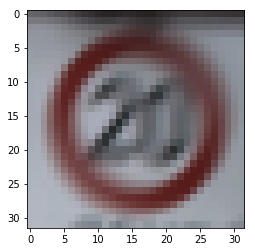

```
Label: 1 - Speed limit (30km/h) , Count: 690
Indexes [2220 2221 2222 ... 4197 4198 4199]
y-val [1 1 1 ... 1 1 1]
```

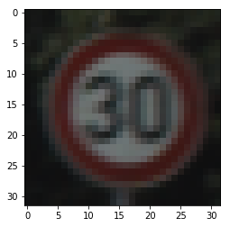

```
Label: 2 - Speed limit (50km/h) , Count: 330
Indexes [31439 31440 31441 ... 33446 33447 33448]
y-val [2 2 2 ... 2 2 2]
```

[figure not shown]

```
Label: 3 - Speed limit (60km/h) , Count: 540
Indexes [5370 5371 5372 ... 6627 6628 6629]
y-val [3 3 3 ... 3 3 3]
```

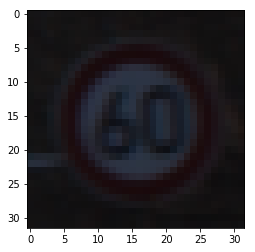

```
Label: 4 - Speed limit (70km/h) , Count: 450
Indexes [6810 6811 6812 ... 8577 8578 8579]
y-val [4 4 4 ... 4 4 4]
```

[figure not shown]

```
Label: 5 - Speed limit (80km/h) , Count: 1980
Indexes [12360 12361 12362 ... 14007 14008 14009]
y-val [5 5 5 ... 5 5 5]
```

[figure not shown]

[output not shown]

[output cut: 26 more lines]

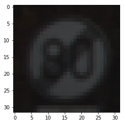

```
Label: 7 - Speed limit (100km/h) , Count: 330
Indexes [23730 23731 23732 ... 25017 25018 25019]
y-val [7 7 7 ... 7 7 7]
```

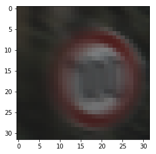

```
Label: 8 - Speed limit (120km/h) , Count: 180
Indexes [15870 15871 15872 ... 17127 17128 17129]
y-val [8 8 8 ... 8 8 8]
```

[figure not shown]

```
Label: 9 - No passing , Count: 360
Indexes [11040 11041 11042 ... 12357 12358 12359]
y-val [9 9 9 ... 9 9 9]
```

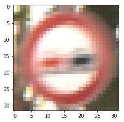

```
Label: 10 - No passing for vehicles over 3.5 metric tons , Count: 1260
Indexes [17130 17131 17132 ... 18927 18928 18929]
y-val [10 10 10 ... 10 10 10]
```

[figure not shown]

```
Label: 11 - Right-of-way at the next intersection , Count: 180
Indexes [8580 8581 8582 ... 9747 9748 9749]
y-val [11 11 11 ... 11 11 11]
```

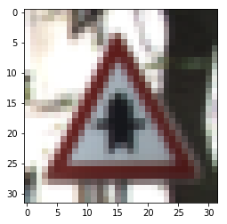

```
Label: 12 - Priority road , Count: 1770
Indexes [27329 27330 27331 ... 29216 29217 29218]
y-val [12 12 12 ... 12 12 12]
```

[31 more figures not shown]

```python
### Data exploration visualization code goes here.
### Feel free to use as many code cells as needed.
# Visualizations will be shown in the notebook.
import matplotlib.pyplot as plt
import numpy as np
import random
from collections import Counter
with tf.device('/cpu:0'):
    df = pandas.read_csv('signnames.csv')
    data = df.values

    #f, axarr = plt.subplots(4, 1)

    #batch_size = 34799

    arr_rand = [0, 1, 2, 3, 4, 5]
    secure_random = random.SystemRandom()
    step = secure_random.choice(arr_rand)

    run_options = tf.RunOptions(report_tensor_allocations_upon_oom = True)
    X_train_display = X_train
    with tf.Session() as sess:
        #y_train_output = sess.run([y_train],  options=run_options)

        #y_train_output = tf.cast(y_train_output, tf.int32)
        shape = [X_train_display.shape[0], X_train_display.shape[1], X_train_display.shape[2], X_train_display.shape[3]]
        #X_train_np = []
        #X_train_tensor_output = sess.run([X_train_tensor])
        #for i in range(X_train_tensor.shape[0]):
            #X_train_tensor_output = X_train_tensor[i]
            #print(X_train_tensor_output.shape)
            #X_train_np_out= sess.run([X_train_tensor_output],  options=run_options)
           # X_train_np = np.concat(X_train_np, X_train_np_out)
        #X_train_tensor_output_1_5 = sess.run([X_train_tensor])
        #X_train_tensor_output = sess.run([X_train_tensor])
        #X_train_tensor_output = np.array(X_train_tensor_output).T
        #print(X_train_np.shape)

        #y_train_output = np.array(y_train_output)
        y_train_output = tf.cast(y_train, dtype=tf.int32)
        y_train_output = sess.run([ y_train_output],  options=run_options)
        y_train_output = np.array(y_train_output).T
        print(y_train_output.shape)
        #X_train_tensor = tf.cast(X_train_tensor, dtype=np.uint8)
        count_aray = []
        for j in range(len(data)):
            count = counts[data[j][0]]
            count_aray.append(count)
            print('Label:',data[j][0],"-", data[j][1],", Count:",count)
            print('Indexes', np.nonzero(idx_train== np.nonzero(uniques == j))[1] )
            print('y-val', y_train[np.nonzero(idx_train== np.nonzero(uniques == j))[1]])
            plt.imshow(X_train_display[np.nonzero(idx_train== np.nonzero(uniques == j))[1]][179].reshape(X_train_display.shape[1], X_train_display.shape[2], X_train_display.shape[3]), cmap=plt.cm.gray, interpolation='nearest')
            plt.show()
```

# %matplotlib notebook

# plt.rcParams['figure.figsize'] = [10, 6]

print(X_train.shape )

```
    #print(image)
    count = counts[y_train_output[i][0]]
    #image = sess.run([X_train_tensor[i]])
    #print(image)
    print('Label:',y_train_output[i][0],"-", data[y_train_output[i][0]][1],", Count:",count)
    #axarr[j].imshow(image)
    plt.imshow(image)
    plt.show()
    #j+=1
```

## Step 2: Design and Test a Model Architecture

Design and implement a deep learning model that learns to recognize traffic signs. Train and test your model on the [German Traffic Sign Dataset](http://benchmark.ini.rub.de/?section=gtsrb&subsection=dataset).

The LeNet-5 implementation shown in the classroom at the end of the CNN lesson is a solid starting point. You'll have to change the number of classes and possibly the preprocessing, but aside from that it's plug and play!

With the LeNet-5 solution from the lecture, you should expect a validation set accuracy of about 0.89. To meet specifications, the validation set accuracy will need to be at least 0.93. It is possible to get an even higher accuracy, but 0.93 is the minimum for a successful project submission.

There are various aspects to consider when thinking about this problem:

- Neural network architecture (is the network over or underfitting?)
- Play around preprocessing techniques (normalization, rgb to grayscale, etc)
- Number of examples per label (some have more than others).
- Generate fake data.

Here is an example of a [published baseline model on this problem](http://yann.lecun.com/exdb/publis/pdf/sermanet-ijcnn-11.pdf). It's not required to be familiar with the approach used in the paper but, it's good practice to try to read papers like these.

### Pre-process the Data Set (normalization, grayscale, etc.)

Minimally, the image data should be normalized so that the data has mean zero and equal variance. For image data, `(pixel - 128)/ 128` is a quick way to approximately normalize the data and can be used in this project.

Other pre-processing steps are optional. You can try different techniques to see if it improves performance.

Use the code cell (or multiple code cells, if necessary) to implement the first step of your project.

```python
# From https://www.kaggle.com
def vtoimg(v):
     return np.array(np.clip(v, 0, 255), dtype=np.uint8).reshape(3,32,32).transpose([1,2,0])
# From https://www.kaggle.com
def whiten(pca, vec):
    QQ = np.dot(vec - pca.mean_, pca.components_.T)
    return np.dot(QQ / pca.singular_values_, pca.components_) * np.sqrt(60000) * 64 + 128
```

### Preprocess the data here. It is required to normalize the data. Other preprocessing steps could include

### converting to grayscale, etc.

### Feel free to use as many code cells as needed.

```
# PCA / ZCA whitening
#from sklearn.decomposition import PCA
#pca = PCA(n_components=400, random_state=0, svd_solver='randomized')
#num_examples, nx, ny, channels = X_train.shape

#        np_X_train = X_train.eval(sess)
 #       pca.fit(np_X_train)

#for i in range(X_train.shape[0]):
 #   X_train = vtoimg(whiten(pca, X_train[i]))
#    X_valid = vtoimg(whiten(pca, X_valid[i]))
#    X_test = vtoimg(whiten(pca, X_test[i]))
#with tf.Session() as sess:
n_samp, nx, ny, channels = X_train_tensor.shape
    #X_train = sess.run(X_train)
#print(X_train.dtype)
#n_samp_float = tf.cast((n_samp), tf.float32)
#n_samp_float_mod = n_samp_float * tf.cast((nx), tf.float32) * tf.cast((ny), tf.float32)
#channels = tf.cast((channels), tf.float32)
#X_train = tf.cast(X_train, tf.float32)
#X_train_mod = tf.reshape(X_train, [n_samp_float_mod, channels])
X_train_tensor = tf.cast(X_train_tensor, tf.float32)

X_valid = tf.cast(X_valid, tf.float32)
X_test = tf.cast(X_test, tf.float32)
# Convert to grayscale
#gray_aray =  tf.cast([0.2989, 0.5870, 0.1140],tf.float32 )
#gray_aray = tf.transpose(gray_aray)
#print(gray_aray.shape)
#train_temp = tf.dot(X_train_tensor, gray_tran)
#_train_temp = tf.multiply(X_train_tensor, tf.cast(gray_tran),tf.float32)
#print(X_train_temp.shape)
#X_train_mod = tf.reduce_sum(X_train_temp, 0)
#X_train_mod= tf.matmul(X_train_tensor, gray_tran)
#X_train_mod = np.dot(X_train_tensor, gray_aray )
#X_train_mod = tf.reshape(n_samp, nx, ny)
#X_valid_mod= (np.dot(X_valid, [0.2989, 0.5870, 0.1140]))
#X_test_mod= (np.dot(X_test, [0.2989, 0.5870, 0.1140]))
#X_train_mod = sess.run(X_train_mod)
#np_X_train = X_train_mod.eval(sess)
#print(X_train_mod.shape)
#batch_size = 102350
# = (X_train_tensor.shape[0], X_train_tensor.shape[1], X_train_tensor.shape[2], X_train_tensor.shape[3])
#iter_max = X_train_tensor.shape[0] // batch_size
#X_train_mod_aray = []
#print(iter_max)
#x_temp = X_train_tensor[0:batch_size]
#gray_scale_img_concat = tf.image.rgb_to_grayscale(x_temp)

#for i in range(1,iter_max):
    #x_temp = X_train_tensor[(i * batch_size):((i+1) * batch_size)]

    #gray_scale_img_concat = tf.concat((gray_scale_img_concat, gray_scale_img), axis = 0)
#X_train = gray_scale_img_concat

X_train = tf.image.rgb_to_grayscale(X_train_tensor)
X_valid = tf.image.rgb_to_grayscale(X_valid)
X_test = tf.image.rgb_to_grayscale(X_test)
#X_train = X_train_tensor
print(X_train.shape)
```

```python
#gray = 0.2989 * r + 0.5870 * g + 0.1140 * b
X_train = np.dot(X_train[...,:3], [0.299, 0.587, 0.114])
X_train = X_train.reshape(X_train.shape[0], X_train.shape[1], X_train.shape[2], 1)

X_valid = np.dot(X_valid[...,:3], [0.299, 0.587, 0.114])
X_valid = X_valid.reshape(X_valid.shape[0], X_valid.shape[1], X_valid.shape[2], 1)

X_test = np.dot(X_test[...,:3], [0.299, 0.587, 0.114])
X_test = X_test.reshape(X_test.shape[0], X_test.shape[1], X_test.shape[2], 1)
print("X.train.grayscale", X_train[0], X_train.shape)
```

```
X.train.grayscale [[[25.783]
  [24.783]
  [24.669]
  ...
  [28.74 ]
  [27.968]
  [28.082]]

 [[26.783]
  [25.37 ]
  [25.37 ]
  ...
  [28.74 ]
  [27.854]
  [27.669]]

 [[26.598]
  [25.37 ]
  [25.071]
  ...
  [28.74 ]
  [27.854]
  [27.669]]

 ...

 [[24.783]
  [25.783]
  [26.381]
  ...
  [24.783]
  [24.968]
  [25.854]]

 [[24.495]
  [25.495]
  [26.68 ]
  ...
  [24.783]
  [24.968]
  [24.854]]

 [[24.794]
  [25.794]
  [26.278]
  ...
  [24.669]
  [23.968]
  [22.968]]] (34799, 32, 32, 1)
```

```python
# Normalize training data.
X_train = np.divide(np.subtract(X_train, 128), 128)
print("X.train.normalized", X_train[0], X_train.shape)



# Normalize validation data.
X_valid = np.divide(np.subtract(X_valid, 128), 128)


# Normalize test data.
X_test = np.divide(np.subtract(X_test, 128), 128)
```

```
X.train.normalized [[[-0.79857031]
  [-0.80638281]
  [-0.80727344]
  ...
  [-0.77546875]
  [-0.7815    ]
  [-0.78060938]]

 [[-0.79075781]
  [-0.80179687]
  [-0.80179687]
  ...
  [-0.77546875]
  [-0.78239063]
  [-0.78383594]]

 [[-0.79220313]
  [-0.80179687]
  [-0.80413281]
  ...
  [-0.77546875]
  [-0.78239063]
  [-0.78383594]]

 ...

 [[-0.80638281]
  [-0.79857031]
  [-0.79389844]
  ...
  [-0.80638281]
  [-0.8049375 ]
  [-0.79801563]]

 [[-0.80863281]
  [-0.80082031]
  [-0.7915625 ]
  ...
  [-0.80638281]
  [-0.8049375 ]
  [-0.80582813]]

 [[-0.80629688]
  [-0.79848438]
  [-0.79470313]
  ...
  [-0.80727344]
  [-0.81275   ]
  [-0.8205625 ]]] (34799, 32, 32, 1)
```

```
# Normalize training data.
X_train = tf.divide(tf.subtract(X_train, 128), 128)
print("X.train.normalized", X_train[0], X_train.shape)



# Normalize validation data.
X_valid = tf.divide(tf.subtract(X_valid, 128), 128)
#nsamples, nx, ny, channels = X_valid_mod.get_shape()
#d2_valid_dataset = tf.reshape(X_valid_mod, ((nsamples,nx*ny*channels)))
#X_valid = normalize(d2_valid_dataset)
#X_valid =  tf.reshape(X_valid.reshape,((nsamples,nx,ny,1)))

# Normalize test data.
X_test = tf.divide(tf.subtract(X_test, 128), 128)
#nsamples, nx, ny, channels = X_test_mod.get_shape()
#d2_test_dataset = tf.reshape(X_test_mod((nsamples,nx*ny*channels)))
#X_test = normalize(d2_test_dataset)
#X_test = tf.reshape(X_test((nsamples,nx,ny,1)))

# Histogram Equalizer
#X_train = cv2.equalizeHist(X_train)
#X_valid = cv2.equalizeHist(X_valid)
#X_test = cv2.equalizeHist(X_test)


from sklearn.utils import shuffle
# Shuffle the training data.
#X_train = tf.random_shuffle(X_train)
#y_train = tf.random_shuffle(y_train)
#X_train, y_train = shuffle(X_train, y_train)
```

### Model Architecture

```python
### Define your architecture here.
### Feel free to use as many code cells as needed.
import tensorflow as tf
with tf.device('/cpu:0'):
    EPOCHS = 200
    BATCH_SIZE = 128

    # Arguments used for tf.truncated_normal, randomly defines variables for the weights and biases for each layer
    mu = 0
    sigma = 0.1
    # Store layers weight & bias

    weights = {
        'wc1': tf.Variable(tf.random_normal([5, 5, 1, 6], mean = mu, stddev = sigma)),
        'wc2': tf.Variable(tf.random_normal([5, 5, 6, 16], mean = mu, stddev = sigma)),
        'wd1': tf.Variable(tf.random_normal([5*5*16, 120], mean = mu, stddev = sigma)),
        'wd2': tf.Variable(tf.random_normal([120, 84], mean = mu, stddev = sigma)),
        'out': tf.Variable(tf.random_normal([84, n_classes], mean = mu, stddev = sigma))}

    biases = {
        'bc1': tf.Variable(tf.random_normal([6])),
        'bc2': tf.Variable(tf.random_normal([16])),
        'bd1': tf.Variable(tf.random_normal([120])),
        'bd2': tf.Variable(tf.random_normal([84])),
        'out': tf.Variable(tf.random_normal([n_classes]))}
```

### Define your architecture here.

### Feel free to use as many code cells as needed.

```
# Arguments used for tf.truncated_normal, randomly defines variables for the weights and biases for each layer
mu = 0
sigma = 0.1
# Store layers weight & bias

weights = {
    'wc1': tf.Variable(tf.random_normal([5, 5, 1, 32], mean = mu, stddev = sigma)),
    'wc2': tf.Variable(tf.random_normal([5, 5, 32, 64], mean = mu, stddev = sigma)),
    'wc3': tf.Variable(tf.random_normal([5, 5, 64, 128], mean = mu, stddev = sigma)),
     #'wd1': tf.Variable(tf.random_normal([2*2*128, 1024], mean = mu, stddev = sigma)),
    'wd1': tf.Variable(tf.random_normal([4*4*32 + 4*4*64 + 2*2*128, 1024], mean = mu, stddev = sigma)),
    'wd2': tf.Variable(tf.random_normal([1024, 512], mean = mu, stddev = sigma)),
    'out': tf.Variable(tf.random_normal([512, n_classes], mean = mu, stddev = sigma))}

biases = {
    'bc1': tf.Variable(tf.random_normal([32])),
    'bc2': tf.Variable(tf.random_normal([64])),
    'bc3': tf.Variable(tf.random_normal([128])),
    'bd1': tf.Variable(tf.random_normal([1024])),
    'bd2': tf.Variable(tf.random_normal([512])),
    'out': tf.Variable(tf.random_normal([n_classes]))}
```

```python
i = 0
def LeNet(x):

    # Layer 1: Convolutional. Input = 32x32x1. Output = 28x28x6.
    strides = 1
    conv1 = tf.nn.conv2d(x, weights['wc1'], strides=[1, strides, strides, 1], padding='VALID')
    conv1 = tf.nn.bias_add(conv1, biases['bc1'])
    # Activation.
    conv1 = tf.nn.relu(conv1)
    # Dropout
    #conv1 = tf.nn.dropout(conv1, keep_prob=0.1)
    # Pooling. Input = 28x28x6. Output = 14x14x6.
    k = 2
    conv1 = tf.nn.max_pool(conv1, ksize=[1, k, k, 1], strides=[1, k, k, 1], padding='VALID')

    # Layer 2: Convolutional. Output = 10x10x16.
    conv2 = tf.nn.conv2d(conv1, weights['wc2'], strides=[1, strides, strides, 1], padding='VALID')
    conv2 = tf.nn.bias_add(conv2, biases['bc2'])
    # Activation.
    conv2 = tf.nn.relu(conv2)
    # Dropout
    #conv2 = tf.nn.dropout(conv2, keep_prob=0.1)
    # Pooling. Input = 10x10x16. Output = 5x5x16.
    conv2 = tf.nn.max_pool(conv2, ksize=[1, k, k, 1], strides=[1, k, k, 1], padding='VALID')
    # Flatten. Input = 5x5x16. Output = 400.
    flatten = tf.contrib.layers.flatten(conv2)

    # Layer 3: Fully Connected. Input = 400. Output = 120.
    fc1 = tf.add(tf.matmul(flatten, weights['wd1']), biases['bd1'])
    # Activation.
    fc1 = tf.nn.relu(fc1)
    # Dropout
    #fc1 = tf.nn.dropout(fc1, keep_prob=0.5)

    # Layer 4: Fully Connected. Input = 120. Output = 84.
    fc2 = tf.add(tf.matmul(fc1, weights['wd2']), biases['bd2'])
    # Activation.
    fc2 = tf.nn.relu(fc2)
     # Dropout
    #fc2 = tf.nn.dropout(fc2, keep_prob=0.5)

    # Layer 5: Softmax. Input = 84. Output = 43
    logits = tf.add(tf.matmul(fc2, weights['out']), biases['out'])

    return logits
```

```
# Layer 1: Convolutional. Input = 32x32x1. Output = 32x32x32.
strides = 1
conv1 = tf.nn.conv2d(x, weights['wc1'], strides=[1, strides, strides, 1], padding='SAME')
conv1 = tf.nn.bias_add(conv1, biases['bc1'])
# Activation.
conv1 = tf.nn.relu(conv1)
# Dropout
#conv1 = tf.nn.dropout(conv1, keep_prob=0.9)
# Pooling. Input = 32x32x32. Output = 16x16x32.
k = 2
conv1 = tf.nn.max_pool(conv1, ksize=[1, k, k, 1], strides=[1, k, k, 1], padding='VALID')

# Layer 2: Convolutional. input 16x16x32.  Output = 16x16x64.
conv2 = tf.nn.conv2d(conv1, weights['wc2'], strides=[1, strides, strides, 1], padding='SAME')
conv2 = tf.nn.bias_add(conv2, biases['bc2'])
# Activation.
conv2 = tf.nn.relu(conv2)
# Dropout
#conv2 = tf.nn.dropout(conv2, keep_prob=0.8)
# Pooling. Input = 16x16x64. Output = 8x8x64.
conv2 = tf.nn.max_pool(conv2, ksize=[1, k, k, 1], strides=[1, k, k, 1], padding='VALID')

# Layer 3: Convolutional. input = 8x8x64.  Output = 4x4x128.
conv3 = tf.nn.conv2d(conv2, weights['wc3'], strides=[1, strides, strides, 1], padding='VALID')
conv3 = tf.nn.bias_add(conv3, biases['bc3'])
# Activation.
conv3 = tf.nn.relu(conv3)
# Dropout
#conv3 = tf.nn.dropout(conv3, keep_prob=0.7)
# Pooling. Input = 4x4x128. Output = 2x2x128.
conv3 = tf.nn.max_pool(conv3, ksize=[1, k, k, 1], strides=[1, k, k, 1], padding='VALID')

k = 4
# Input = 16x16x32, Output = 4x4x32
conv1 = tf.nn.max_pool(conv1, ksize=[1, k, k, 1], strides=[1, k, k, 1], padding='VALID')
#shape = conv1.get_shape().as_list()
#conv1 = tf.reshape(conv1, [-1, shape[1] * shape[2] * shape[3]])
k = 2
# Input = 8x8x64, Output = 4x4x64
conv2 = tf.nn.max_pool(conv2, ksize=[1, k, k, 1], strides=[1, k, k, 1], padding='VALID')
#shape = conv2.get_shape().as_list()
#conv2 = tf.reshape(conv2, [-1, shape[1] * shape[2] * shape[3]])


#shape = conv3.get_shape().as_list()
#conv3 = tf.reshape(conv3, [-1, shape[1] * shape[2] * shape[3]])

# Flatten. Input = 4x4x32 + 4x4x64 + 2x2x128=2048.
#flatten = tf.contrib.layers.flatten(tf.concat(1, [conv1, conv2, conv3]))

flatten1 = tf.contrib.layers.flatten(conv1)
print("dffds", flatten1)
flatten2 = tf.contrib.layers.flatten(conv2)
print("dffds", flatten2.shape)
flatten3 = tf.contrib.layers.flatten(conv3)
#flatten = tf.concat([conv1, conv2, conv3], 1)
flatten = tf.concat((flatten1, flatten2, flatten3), axis=1)
print("dffds", flatten)
print("dffds", flatten.shape)
#print("dffds", flatten.shape)
# Layer 3: Fully Connected. Input = 2048. Output = 1024.
fc1 = tf.add(tf.matmul(flatten, weights['wd1']), biases['bd1'])
# Activation.
fc1 = tf.nn.relu(fc1)
# Dropout
#fc1 = tf.nn.dropout(fc1, keep_prob=0.5)

# Layer 4: Fully Connected. Input = 1024. Output = 512.
fc2 = tf.add(tf.matmul(fc1, weights['wd2']), biases['bd2'])
# Activation.
fc2 = tf.nn.relu(fc2)
# Dropout
#fc2 = tf.nn.dropout(fc2, keep_prob=0.5)


# Layer 5: Fully Connected. Input = 512. Output = 43
logits = tf.add(tf.matmul(fc2, weights['out']), biases['out'])

return logits
```

```python
x = tf.placeholder(tf.float32, (None, 32, 32, 1))
y = tf.placeholder(tf.int32, (None))
one_hot_y = tf.one_hot(y, n_classes)
```

```python
rate = 0.001

logits = LeNet(x)
cross_entropy = tf.nn.softmax_cross_entropy_with_logits_v2(labels=one_hot_y, logits=logits)
loss_operation = tf.reduce_mean(cross_entropy)
optimizer = tf.train.AdamOptimizer(learning_rate = rate)
#optimizer = tf.train.GradientDescentOptimizer(learning_rate = rate)
training_operation = optimizer.minimize(loss_operation)
```

### Train, Validate and Test the Model

A validation set can be used to assess how well the model is performing. A low accuracy on the training and validation sets imply underfitting. A high accuracy on the training set but low accuracy on the validation set implies overfitting.

```python
### Train your model here.
### Calculate and report the accuracy on the training and validation set.
### Once a final model architecture is selected,
### the accuracy on the test set should be calculated and reported as well.
### Feel free to use as many code cells as needed.

correct_prediction = tf.equal(tf.argmax(logits, 1), tf.argmax(one_hot_y, 1))
accuracy_operation = tf.reduce_mean(tf.cast(correct_prediction, tf.float32))
saver = tf.train.Saver()

def evaluate(X_data, y_data):
    num_examples = len(X_data)
    total_accuracy = 0
    sess = tf.get_default_session()
    for offset in range(0, num_examples, BATCH_SIZE):
        batch_x, batch_y = X_data[offset:offset+BATCH_SIZE], y_data[offset:offset+BATCH_SIZE]
        accuracy = sess.run(accuracy_operation, feed_dict={x: batch_x, y: batch_y})
        total_accuracy += (accuracy * len(batch_x))
    return total_accuracy / num_examples
```

```
#X_train_dataset = tf.data.Dataset.from_tensor_slices(X_train_tensor)
#X_train_dataset = X_train_dataset.prefetch(1)
#iter = X_train_dataset.make_initializable_iterator()
#el = iter.get_next()
with tf.Session(config = session_conf) as sess:
    #sess.run(iter.initializer)
    X_train = sess.run(X_train)
    y_train = sess.run(y_train)

    X_valid = sess.run(X_valid)
    X_test = sess.run(X_test)
    #print(sess.run(el))
    #print(sess.run(el))
   # print(sess.run(el))
print(X_train[0], y_train[0])
```

os.environ["CUDA_VISIBLE_DEVICES"] = '0'

```python
from sklearn.utils import shuffle

config_sess = tf.ConfigProto(allow_soft_placement=True, log_device_placement=True)
config_sess.gpu_options.allow_growth = True
with tf.device('/device:GPU:0'):
    with tf.Session(config = config_sess) as sess:
        sess.run(tf.global_variables_initializer())
        #num_examples = len(X_train)
        num_examples = X_train.shape[0]

        print("Training...")
        print()
        for i in range(EPOCHS):
            X_train, y_train = shuffle(X_train, y_train)
            #X_train, y_train = tf.random_shuffle(X_train), tf.random_shuffle(y_train)

            for offset in range(0, num_examples, BATCH_SIZE):
                end = offset + BATCH_SIZE
                batch_x, batch_y = X_train[offset:end], y_train[offset:end]
                #batch_x, batch_y = sess.run([batch_x, batch_y])
                #batch_x.eval(sess)

                #batch_y = np.array(batch_y[0])
                #batch_y = sess.run(batch_y)
                #batch_x = sess.run(batch_x)
                #print(batch_y)
                #print(batch_x)

                sess.run(training_operation, feed_dict={x: batch_x, y: batch_y})


            training_accuracy = evaluate(X_train, y_train)
            validation_accuracy = evaluate(X_valid, y_valid)
            print("EPOCH {} ...".format(i+1))
            print("Training Accuracy = {:.3f}".format(training_accuracy))
            print("Validation Accuracy = {:.3f}".format(validation_accuracy))
            print()

        saver.save(sess, './traffic_sign_classifier')
        print("Model saved")
```

```
Training...

EPOCH 1 ...
Training Accuracy = 0.560
Validation Accuracy = 0.520

EPOCH 2 ...
Training Accuracy = 0.848
Validation Accuracy = 0.774

EPOCH 3 ...
Training Accuracy = 0.921
Validation Accuracy = 0.849

EPOCH 4 ...
Training Accuracy = 0.947
Validation Accuracy = 0.863

EPOCH 5 ...
Training Accuracy = 0.964
Validation Accuracy = 0.878

EPOCH 6 ...
Training Accuracy = 0.963
Validation Accuracy = 0.872

EPOCH 7 ...
Training Accuracy = 0.971
Validation Accuracy = 0.883

EPOCH 8 ...
Training Accuracy = 0.975
Validation Accuracy = 0.891

EPOCH 9 ...
Training Accuracy = 0.982
Validation Accuracy = 0.893

EPOCH 10 ...
Training Accuracy = 0.977
```

[output cut: 748 more lines]

```
Validation Accuracy = 0.934

EPOCH 198 ...
Training Accuracy = 1.000
Validation Accuracy = 0.934

EPOCH 199 ...
Training Accuracy = 1.000
Validation Accuracy = 0.933

EPOCH 200 ...
Training Accuracy = 1.000
Validation Accuracy = 0.934

Model saved
```

```python
with tf.Session() as sess:
    saver.restore(sess, './traffic_sign_classifier')

    test_accuracy = evaluate(X_test, y_test)
    print("Test Accuracy = {:.3f}".format(test_accuracy))
```

```
INFO:tensorflow:Restoring parameters from ./traffic_sign_classifier
Test Accuracy = 0.920
```

## Step 3: Test a Model on New Images

To give yourself more insight into how your model is working, download at least five pictures of German traffic signs from the web and use your model to predict the traffic sign type.

You may find `signnames.csv` useful as it contains mappings from the class id (integer) to the actual sign name.

### Load and Output the Images

[output not shown]

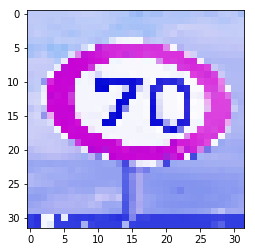

[output not shown]

[figure not shown]

[output not shown]

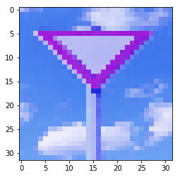

[output not shown]

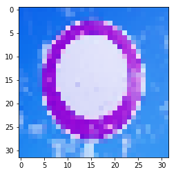

[output not shown]

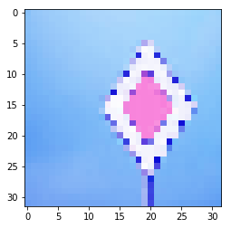

```python
### Load the images and plot them here.
import matplotlib.pyplot as plt
import matplotlib.image as mpimg
from skimage.transform import resize
y_newtest = [4, 14, 13, 15, 12]
X_newtest = np.float32(np.zeros((5,32,32,1)))
#reading in an image
image = mpimg.imread('traffic_signs_data/70kmph.png')
image = resize(image, (32, 32,3))
plt.imshow(image)
image = np.dot(image[...,:3], [0.299, 0.587, 0.114])
image = image.reshape(image.shape[0], image.shape[1], 1)
image = np.divide(np.subtract(image, 128), 128)
X_newtest[0] = image
#printing out some stats and plotting
print('This image is with dimensions:', image.shape)
plt.show()

#reading in an image
image = mpimg.imread('traffic_signs_data/stop.png')
image = resize(image, (32, 32, 3))
plt.imshow(image)
image = np.dot(image[...,:3], [0.299, 0.587, 0.114])
image = image.reshape(image.shape[0], image.shape[1], 1)
image = np.divide(np.subtract(image, 128), 128)
X_newtest[1] = image

plt.show()

#reading in an image
image = mpimg.imread('traffic_signs_data/yield.png')
image = resize(image, (32, 32, 3))
plt.imshow(image)
image = np.dot(image[...,:3], [0.299, 0.587, 0.114])
image = image.reshape(image.shape[0], image.shape[1], 1)
image = np.divide(np.subtract(image, 128), 128)
X_newtest[2] = image

plt.show()

#reading in an image
image = mpimg.imread('traffic_signs_data/no_vehicles.png')
image = resize(image, (32, 32, 3))
plt.imshow(image)
image = np.dot(image[...,:3], [0.299, 0.587, 0.114])
image = image.reshape(image.shape[0], image.shape[1], 1)
image = np.divide(np.subtract(image, 128), 128)
X_newtest[3] = image

plt.show()

#reading in an image
image = mpimg.imread('traffic_signs_data/priority_road.png')
image = resize(image, (32, 32, 3))
plt.imshow(image)
image = np.dot(image[...,:3], [0.299, 0.587, 0.114])
image = image.reshape(image.shape[0], image.shape[1], 1)
image = np.divide(np.subtract(image, 128), 128)
X_newtest[4] = image



plt.show()
### Feel free to use as many code cells as needed.
```

### Predict the Sign Type for Each Image

```python
### Run the predictions here and use the model to output the prediction for each image.
### Make sure to pre-process the images with the same pre-processing pipeline used earlier.
### Feel free to use as many code cells as needed.
#X_newtest = X_newtest.reshape((-1, 32, 32, 1)).astype(np.float32)
#X_newtest = np.divide(np.subtract(X_newtest, 128), 128)
with tf.Session() as sess:
    saver.restore(sess, './traffic_sign_classifier')
    correct_pred = sess.run(tf.argmax(logits, 1), feed_dict={x: X_newtest})

    #c_predict = sess.run(correct_pred)
    for idx in range(5):
        #plt.imshow(X_newtest[idx], cmap='gray')
        #plt.title(data[correct_pred[idx]][0])
        print(correct_pred[idx])
        #print(correct_prediction[idx])
        #print(data[correct_pred[idx]][1])
        #plt.axis('off')
    #plt.show()
```

```
INFO:tensorflow:Restoring parameters from ./traffic_sign_classifier
3
3
3
3
3
```

### Analyze Performance

```python
### Calculate the accuracy for these 5 new images.
### For example, if the model predicted 1 out of 5 signs correctly, it's 20% accurate on these new images.
0%
```

### Output Top 5 Softmax Probabilities For Each Image Found on the Web

For each of the new images, print out the model's softmax probabilities to show the **certainty** of the model's predictions (limit the output to the top 5 probabilities for each image). [`tf.nn.top_k`](https://www.tensorflow.org/versions/r0.12/api_docs/python/nn.html#top_k) could prove helpful here.

The example below demonstrates how tf.nn.top_k can be used to find the top k predictions for each image.

`tf.nn.top_k` will return the values and indices (class ids) of the top k predictions. So if k=3, for each sign, it'll return the 3 largest probabilities (out of a possible 43) and the correspoding class ids.

Take this numpy array as an example. The values in the array represent predictions. The array contains softmax probabilities for five candidate images with six possible classes. `tf.nn.top_k` is used to choose the three classes with the highest probability:

```
# (5, 6) array
a = np.array([[ 0.24879643,  0.07032244,  0.12641572,  0.34763842,  0.07893497,
         0.12789202],
       [ 0.28086119,  0.27569815,  0.08594638,  0.0178669 ,  0.18063401,
         0.15899337],
       [ 0.26076848,  0.23664738,  0.08020603,  0.07001922,  0.1134371 ,
         0.23892179],
       [ 0.11943333,  0.29198961,  0.02605103,  0.26234032,  0.1351348 ,
         0.16505091],
       [ 0.09561176,  0.34396535,  0.0643941 ,  0.16240774,  0.24206137,
         0.09155967]])
```

Running it through `sess.run(tf.nn.top_k(tf.constant(a), k=3))` produces:

```
TopKV2(values=array([[ 0.34763842,  0.24879643,  0.12789202],
       [ 0.28086119,  0.27569815,  0.18063401],
       [ 0.26076848,  0.23892179,  0.23664738],
       [ 0.29198961,  0.26234032,  0.16505091],
       [ 0.34396535,  0.24206137,  0.16240774]]), indices=array([[3, 0, 5],
       [0, 1, 4],
       [0, 5, 1],
       [1, 3, 5],
       [1, 4, 3]], dtype=int32))
```

Looking just at the first row we get `[ 0.34763842, 0.24879643, 0.12789202]`, you can confirm these are the 3 largest probabilities in `a`. You'll also notice `[3, 0, 5]` are the corresponding indices.

```python
### Print out the top five softmax probabilities for the predictions on the German traffic sign images found on the web.
### Feel free to use as many code cells as needed.
with tf.Session() as sess:
    saver.restore(sess, './traffic_sign_classifier')
    correct_prob = sess.run(tf.nn.softmax(logits), feed_dict={x: X_newtest})
    top_5 = tf.nn.top_k(correct_prob, k=5)
    correct_pred_top_5 = sess.run(top_5)
    for idx in range(5):
        #plt.imshow(X_newtest[idx])
        print(correct_pred_top_5.values[idx:])
        print(data[correct_pred_top_5.indices[idx:],0])



    #plt.show()
```

```
INFO:tensorflow:Restoring parameters from ./traffic_sign_classifier
[[9.8548776e-01 7.5418502e-03 3.3757300e-03 2.3093659e-03 6.0939702e-04]
 [9.8038059e-01 1.1434657e-02 3.9610234e-03 2.4156836e-03 6.9850113e-04]
 [9.7218770e-01 1.8986085e-02 3.8553888e-03 2.2549105e-03 1.2996516e-03]
 [9.8385608e-01 6.1478778e-03 6.0918378e-03 2.5152806e-03 4.8459703e-04]
 [9.8326010e-01 1.0538182e-02 2.5541489e-03 2.2845601e-03 6.7034567e-04]]
[[3 5 9 25 33]
 [3 5 9 25 7]
 [3 5 25 9 7]
 [3 9 5 25 7]
 [3 5 9 25 7]]
[[9.8038059e-01 1.1434657e-02 3.9610234e-03 2.4156836e-03 6.9850113e-04]
 [9.7218770e-01 1.8986085e-02 3.8553888e-03 2.2549105e-03 1.2996516e-03]
 [9.8385608e-01 6.1478778e-03 6.0918378e-03 2.5152806e-03 4.8459703e-04]
 [9.8326010e-01 1.0538182e-02 2.5541489e-03 2.2845601e-03 6.7034567e-04]]
[[3 5 9 25 7]
 [3 5 25 9 7]
 [3 9 5 25 7]
 [3 5 9 25 7]]
[[9.7218770e-01 1.8986085e-02 3.8553888e-03 2.2549105e-03 1.2996516e-03]
 [9.8385608e-01 6.1478778e-03 6.0918378e-03 2.5152806e-03 4.8459703e-04]
 [9.8326010e-01 1.0538182e-02 2.5541489e-03 2.2845601e-03 6.7034567e-04]]
[[3 5 25 9 7]
 [3 9 5 25 7]
 [3 5 9 25 7]]
[[9.8385608e-01 6.1478778e-03 6.0918378e-03 2.5152806e-03 4.8459703e-04]
 [9.8326010e-01 1.0538182e-02 2.5541489e-03 2.2845601e-03 6.7034567e-04]]
[[3 9 5 25 7]
 [3 5 9 25 7]]
[[9.8326010e-01 1.0538182e-02 2.5541489e-03 2.2845601e-03 6.7034567e-04]]
[[3 5 9 25 7]]
```

### Project Writeup

Once you have completed the code implementation, document your results in a project writeup using this [template](https://github.com/udacity/CarND-Traffic-Sign-Classifier-Project/blob/master/writeup_template.md) as a guide. The writeup can be in a markdown or pdf file.

## Step 4 (Optional): Visualize the Neural Network's State with Test Images

This Section is not required to complete but acts as an additional excersise for understaning the output of a neural network's weights. While neural networks can be a great learning device they are often referred to as a black box. We can understand what the weights of a neural network look like better by plotting their feature maps. After successfully training your neural network you can see what it's feature maps look like by plotting the output of the network's weight layers in response to a test stimuli image. From these plotted feature maps, it's possible to see what characteristics of an image the network finds interesting. For a sign, maybe the inner network feature maps react with high activation to the sign's boundary outline or to the contrast in the sign's painted symbol.

Provided for you below is the function code that allows you to get the visualization output of any tensorflow weight layer you want. The inputs to the function should be a stimuli image, one used during training or a new one you provided, and then the tensorflow variable name that represents the layer's state during the training process, for instance if you wanted to see what the LeNet lab's feature maps looked like for it's second convolutional layer you could enter conv2 as the tf_activation variable.

For an example of what feature map outputs look like, check out NVIDIA's results in their paper [End-to-End Deep Learning for Self-Driving Cars](https://devblogs.nvidia.com/parallelforall/deep-learning-self-driving-cars/) in the section Visualization of internal CNN State. NVIDIA was able to show that their network's inner weights had high activations to road boundary lines by comparing feature maps from an image with a clear path to one without. Try experimenting with a similar test to show that your trained network's weights are looking for interesting features, whether it's looking at differences in feature maps from images with or without a sign, or even what feature maps look like in a trained network vs a completely untrained one on the same sign image.

[figure not shown]

Your output should look something like this (above)

```python
### Visualize your network's feature maps here.
### Feel free to use as many code cells as needed.

# image_input: the test image being fed into the network to produce the feature maps
# tf_activation: should be a tf variable name used during your training procedure that represents the calculated state of a specific weight layer
# activation_min/max: can be used to view the activation contrast in more detail, by default matplot sets min and max to the actual min and max values of the output
# plt_num: used to plot out multiple different weight feature map sets on the same block, just extend the plt number for each new feature map entry

def outputFeatureMap(image_input, tf_activation, activation_min=-1, activation_max=-1 ,plt_num=1):
    # Here make sure to preprocess your image_input in a way your network expects
    # with size, normalization, ect if needed
    # image_input =
    # Note: x should be the same name as your network's tensorflow data placeholder variable
    # If you get an error tf_activation is not defined it may be having trouble accessing the variable from inside a function
    activation = tf_activation.eval(session=sess,feed_dict={x : image_input})
    featuremaps = activation.shape[3]
    plt.figure(plt_num, figsize=(15,15))
    for featuremap in range(featuremaps):
        plt.subplot(6,8, featuremap+1) # sets the number of feature maps to show on each row and column
        plt.title('FeatureMap ' + str(featuremap)) # displays the feature map number
        if activation_min != -1 & activation_max != -1:
            plt.imshow(activation[0,:,:, featuremap], interpolation="nearest", vmin =activation_min, vmax=activation_max, cmap="gray")
        elif activation_max != -1:
            plt.imshow(activation[0,:,:, featuremap], interpolation="nearest", vmax=activation_max, cmap="gray")
        elif activation_min !=-1:
            plt.imshow(activation[0,:,:, featuremap], interpolation="nearest", vmin=activation_min, cmap="gray")
        else:
            plt.imshow(activation[0,:,:, featuremap], interpolation="nearest", cmap="gray")
```

```python
outputFeatureMap(x, conv2, activation_min=-1, activation_max=-1 ,plt_num=1)
```

[output not shown]